# Project: Investigate a Dataset of The Movie Database (TMDB)

- Introduction
- Data Wrangling
- Exploratory Data Analysis
- Conclusions
- References

## Introduction

In this project, we will analyze the data set associated with The Movie Database (TMDB). This data set contains information about 10,000 movies collected from The Movie Database (TMDB), including user ratings and revenue. In particular, we will be interrested in finding the trends affect the revenue of the movies and how differet factor affect the maximization of this revenue with respect to the budget. Also, different visualization will be introduced to emphasize the findings and relations affects the revenue of the movies. This project trys to answer the following questions:

- Question 1 (Which genres are most frequently seen from year to year?)
- Question 2 (What kinds of properties are associated with movies that have high revenues?)
- Question 3 (What is the total revenue in each year ?)
- Question 4 (Explain the relation between the total budget and the total revenue in each year ?)
- Question 5 (Explain the relation between the total budget and the total revenue according to movie title ?)
- Question 6 (Is there a relation between the director name and the total revenue? Explain?)
- Question 7 (Explain the relation between the total budget and the total revenue according to vote count and vote average?)

## Data Wrangling

### Import packages and read data file

In this part the required packagea are imported and the dataset is read and the first five rows are displayed to see a sample of the manipulated data.

```python
# import the required packages to be used
import numpy as np
import pandas as pd
import matplotlib.pyplot as plt
import seaborn as sns
%matplotlib inline
```

```python
# read data file and show part of them
df = pd.read_csv('tmdb-movies.csv')
df.head()
```

|  | id | imdb_id | popularity | budget | revenue | original_title | cast | homepage | director | tagline | ... | overview | runtime | genres | production_companies | release_date | vote_count | vote_average | release_year | budget_adj | revenue_adj |
| --- | --- | --- | --- | --- | --- | --- | --- | --- | --- | --- | --- | --- | --- | --- | --- | --- | --- | --- | --- | --- | --- |
| 0 | 135397 | tt0369610 | 32.985763 | 150000000 | 1513528810 | Jurassic World | Chris Pratt\|Bryce Dallas Howard\|Irrfan Khan\|Vi... | http://www.jurassicworld.com/ | Colin Trevorrow | The park is open. | ... | Twenty-two years after the events of Jurassic ... | 124 | Action\|Adventure\|Science Fiction\|Thriller | Universal Studios\|Amblin Entertainment\|Legenda... | 6/9/15 | 5562 | 6.5 | 2015 | 1.379999e+08 | 1.392446e+09 |
| 1 | 76341 | tt1392190 | 28.419936 | 150000000 | 378436354 | Mad Max: Fury Road | Tom Hardy\|Charlize Theron\|Hugh Keays-Byrne\|Nic... | http://www.madmaxmovie.com/ | George Miller | What a Lovely Day. | ... | An apocalyptic story set in the furthest reach... | 120 | Action\|Adventure\|Science Fiction\|Thriller | Village Roadshow Pictures\|Kennedy Miller Produ... | 5/13/15 | 6185 | 7.1 | 2015 | 1.379999e+08 | 3.481613e+08 |
| 2 | 262500 | tt2908446 | 13.112507 | 110000000 | 295238201 | Insurgent | Shailene Woodley\|Theo James\|Kate Winslet\|Ansel... | http://www.thedivergentseries.movie/#insurgent | Robert Schwentke | One Choice Can Destroy You | ... | Beatrice Prior must confront her inner demons ... | 119 | Adventure\|Science Fiction\|Thriller | Summit Entertainment\|Mandeville Films\|Red Wago... | 3/18/15 | 2480 | 6.3 | 2015 | 1.012000e+08 | 2.716190e+08 |
| 3 | 140607 | tt2488496 | 11.173104 | 200000000 | 2068178225 | Star Wars: The Force Awakens | Harrison Ford\|Mark Hamill\|Carrie Fisher\|Adam D... | http://www.starwars.com/films/star-wars-episod... | J.J. Abrams | Every generation has a story. | ... | Thirty years after defeating the Galactic Empi... | 136 | Action\|Adventure\|Science Fiction\|Fantasy | Lucasfilm\|Truenorth Productions\|Bad Robot | 12/15/15 | 5292 | 7.5 | 2015 | 1.839999e+08 | 1.902723e+09 |
| 4 | 168259 | tt2820852 | 9.335014 | 190000000 | 1506249360 | Furious 7 | Vin Diesel\|Paul Walker\|Jason Statham\|Michelle ... | http://www.furious7.com/ | James Wan | Vengeance Hits Home | ... | Deckard Shaw seeks revenge against Dominic Tor... | 137 | Action\|Crime\|Thriller | Universal Pictures\|Original Film\|Media Rights ... | 4/1/15 | 2947 | 7.3 | 2015 | 1.747999e+08 | 1.385749e+09 |

5 rows × 21 columns

### General Properties and Data Cleaning

It is important at first to get information about the size of dataset and the data types of the variables (columns)

```python
# get the info about the columns and dtypes
df.info()
```

```
<class 'pandas.core.frame.DataFrame'>
RangeIndex: 10866 entries, 0 to 10865
Data columns (total 21 columns):
 #   Column                Non-Null Count  Dtype
---  ------                --------------  -----
 0   id                    10866 non-null  int64
 1   imdb_id               10856 non-null  object
 2   popularity            10866 non-null  float64
 3   budget                10866 non-null  int64
 4   revenue               10866 non-null  int64
 5   original_title        10866 non-null  object
 6   cast                  10790 non-null  object
 7   homepage              2936 non-null   object
 8   director              10822 non-null  object
 9   tagline               8042 non-null   object
 10  keywords              9373 non-null   object
 11  overview              10862 non-null  object
 12  runtime               10866 non-null  int64
 13  genres                10843 non-null  object
 14  production_companies  9836 non-null   object
 15  release_date          10866 non-null  object
 16  vote_count            10866 non-null  int64
 17  vote_average          10866 non-null  float64
 18  release_year          10866 non-null  int64
 19  budget_adj            10866 non-null  float64
 20  revenue_adj           10866 non-null  float64
dtypes: float64(4), int64(6), object(11)
memory usage: 1.7+ MB
```

```python
# drop some columns  which has no great effect on the considered target (revenue)
col_to_drop = np.array(['id','imdb_id', 'homepage', 'tagline', 'keywords', 'overview', 'production_companies', 'budget_adj', 'revenue_adj'])
df.drop(columns = col_to_drop, inplace = True)
df.head()
```

|  | popularity | budget | revenue | original_title | cast | director | runtime | genres | release_date | vote_count | vote_average | release_year |
| --- | --- | --- | --- | --- | --- | --- | --- | --- | --- | --- | --- | --- |
| 0 | 32.985763 | 150000000 | 1513528810 | Jurassic World | Chris Pratt\|Bryce Dallas Howard\|Irrfan Khan\|Vi... | Colin Trevorrow | 124 | Action\|Adventure\|Science Fiction\|Thriller | 6/9/15 | 5562 | 6.5 | 2015 |
| 1 | 28.419936 | 150000000 | 378436354 | Mad Max: Fury Road | Tom Hardy\|Charlize Theron\|Hugh Keays-Byrne\|Nic... | George Miller | 120 | Action\|Adventure\|Science Fiction\|Thriller | 5/13/15 | 6185 | 7.1 | 2015 |
| 2 | 13.112507 | 110000000 | 295238201 | Insurgent | Shailene Woodley\|Theo James\|Kate Winslet\|Ansel... | Robert Schwentke | 119 | Adventure\|Science Fiction\|Thriller | 3/18/15 | 2480 | 6.3 | 2015 |
| 3 | 11.173104 | 200000000 | 2068178225 | Star Wars: The Force Awakens | Harrison Ford\|Mark Hamill\|Carrie Fisher\|Adam D... | J.J. Abrams | 136 | Action\|Adventure\|Science Fiction\|Fantasy | 12/15/15 | 5292 | 7.5 | 2015 |
| 4 | 9.335014 | 190000000 | 1506249360 | Furious 7 | Vin Diesel\|Paul Walker\|Jason Statham\|Michelle ... | James Wan | 137 | Action\|Crime\|Thriller | 4/1/15 | 2947 | 7.3 | 2015 |

Now the number of columns and rows after dropping some columns is given:

```python
print(f"number of column = {df.shape[1]} and number of rows =  {df.shape[0]}")
```

```
number of column = 12 and number of rows =  10866
```

The data type of the column release_date need to be adjusted to be datetime type.

It is remarked when trying to convert release_date to datetime type that there is a problem because the year is given by two digits which make a confusion for example 66 is converted to 2066 and not 1966.

So, the following code is proposed to complete the year before converting to timedate to avoid ambiguity

```python
a=(df['release_date'].str[-2:] >= '60') & (df['release_date'].str[-3:-2] == '/')
b=(df['release_date'].str[-2:] < '60') & (df['release_date'].str[-3:-2] == '/')
df.loc[a,'release_date'] = df['release_date'].str[:-2] + '19' + df['release_date'].str[-2:]
df.loc[b,'release_date'] = df['release_date'].str[:-2] + '20' + df['release_date'].str[-2:]
df['release_date']
```

```
0          6/9/2015
1         5/13/2015
2         3/18/2015
3        12/15/2015
4          4/1/2015
            ...
10861     6/15/1966
10862    12/21/1966
10863      1/1/1966
10864     11/2/1966
10865    11/15/1966
Name: release_date, Length: 10866, dtype: object
```

Now it is ready to convert it to datetime without ambiguity

```python
df['release_date'] = pd.to_datetime(df['release_date'])
df.head()
```

|  | popularity | budget | revenue | original_title | cast | director | runtime | genres | release_date | vote_count | vote_average | release_year |
| --- | --- | --- | --- | --- | --- | --- | --- | --- | --- | --- | --- | --- |
| 0 | 32.985763 | 150000000 | 1513528810 | Jurassic World | Chris Pratt\|Bryce Dallas Howard\|Irrfan Khan\|Vi... | Colin Trevorrow | 124 | Action\|Adventure\|Science Fiction\|Thriller | 2015-06-09 | 5562 | 6.5 | 2015 |
| 1 | 28.419936 | 150000000 | 378436354 | Mad Max: Fury Road | Tom Hardy\|Charlize Theron\|Hugh Keays-Byrne\|Nic... | George Miller | 120 | Action\|Adventure\|Science Fiction\|Thriller | 2015-05-13 | 6185 | 7.1 | 2015 |
| 2 | 13.112507 | 110000000 | 295238201 | Insurgent | Shailene Woodley\|Theo James\|Kate Winslet\|Ansel... | Robert Schwentke | 119 | Adventure\|Science Fiction\|Thriller | 2015-03-18 | 2480 | 6.3 | 2015 |
| 3 | 11.173104 | 200000000 | 2068178225 | Star Wars: The Force Awakens | Harrison Ford\|Mark Hamill\|Carrie Fisher\|Adam D... | J.J. Abrams | 136 | Action\|Adventure\|Science Fiction\|Fantasy | 2015-12-15 | 5292 | 7.5 | 2015 |
| 4 | 9.335014 | 190000000 | 1506249360 | Furious 7 | Vin Diesel\|Paul Walker\|Jason Statham\|Michelle ... | James Wan | 137 | Action\|Crime\|Thriller | 2015-04-01 | 2947 | 7.3 | 2015 |

ًTo check the duplicated rows and delete them if any

```python
# check the duplicated rows
df.duplicated().sum()
```

```
1
```

There is 1 duplicated row, so we delete this duplication using the following code.

```python
# drop duplicates if any
if df.duplicated().sum().any():
    df.drop_duplicates(inplace =True)
```

```python
# check after dropping duplicates
df.duplicated().sum().any()
```

```
False
```

Now, we investigate the number of rows in each column to see if there are null values. To get the number of null values in each column.

```python
df.isnull().sum()
```

```
popularity         0
budget             0
revenue            0
original_title     0
cast              76
director          44
runtime            0
genres            23
release_date       0
vote_count         0
vote_average       0
release_year       0
dtype: int64
```

As we do not have any information about the missing values in the columns (cast, director and genre) and they are categorical variables, the unknown rows are dropped especially because we have a lot of observations (rows)

```python
df.dropna(inplace =True)
```

To check that there is no longer null values

```python
df.isnull().sum()
```

```
popularity        0
budget            0
revenue           0
original_title    0
cast              0
director          0
runtime           0
genres            0
release_date      0
vote_count        0
vote_average      0
release_year      0
dtype: int64
```

To get some staistical describtion about the data set, we use the following.

```python
df.describe()
```

|  | popularity | budget | revenue | runtime | vote_count | vote_average | release_year |
| --- | --- | --- | --- | --- | --- | --- | --- |
| count | 10731.000000 | 1.073100e+04 | 1.073100e+04 | 10731.000000 | 10731.000000 | 10731.000000 | 10731.000000 |
| mean | 0.652615 | 1.480365e+07 | 4.031989e+07 | 102.468829 | 219.812972 | 5.964710 | 2001.259622 |
| std | 1.004804 | 3.106456e+07 | 1.176524e+08 | 30.493873 | 578.815324 | 0.930283 | 12.820151 |
| min | 0.000188 | 0.000000e+00 | 0.000000e+00 | 0.000000 | 10.000000 | 1.500000 | 1960.000000 |
| 25% | 0.210765 | 0.000000e+00 | 0.000000e+00 | 90.000000 | 17.000000 | 5.400000 | 1995.000000 |
| 50% | 0.387081 | 0.000000e+00 | 0.000000e+00 | 99.000000 | 39.000000 | 6.000000 | 2006.000000 |
| 75% | 0.720889 | 1.600000e+07 | 2.500000e+07 | 112.000000 | 148.000000 | 6.600000 | 2011.000000 |
| max | 32.985763 | 4.250000e+08 | 2.781506e+09 | 900.000000 | 9767.000000 | 9.200000 | 2015.000000 |

It is remarked that there are some rows whose budget or revenue are zero. I consider this is an error in data and since we do not have information to correct this we can exclude them from the analysis. It is also remarked that the budget or the revenueha a very small number which is unlogical to be correct. So I chose a minimum value to be acceptable for the budget or the revenue. I took into consideration a minimum amount of 10000

```python
df = df[(df.revenue >= 10000) & (df.budget >= 10000)]
```

```python
df.describe()
```

|  | popularity | budget | revenue | runtime | vote_count | vote_average | release_year |
| --- | --- | --- | --- | --- | --- | --- | --- |
| count | 3797.000000 | 3.797000e+03 | 3.797000e+03 | 3797.000000 | 3797.000000 | 3797.000000 | 3797.000000 |
| mean | 1.202742 | 3.764910e+07 | 1.092583e+08 | 109.377403 | 534.303661 | 6.173821 | 2001.232815 |
| std | 1.482896 | 4.231056e+07 | 1.773791e+08 | 19.846461 | 884.728306 | 0.791844 | 11.306094 |
| min | 0.001117 | 1.000000e+04 | 1.000000e+04 | 26.000000 | 10.000000 | 2.200000 | 1960.000000 |
| 25% | 0.468045 | 1.000000e+07 | 1.456008e+07 | 96.000000 | 73.000000 | 5.700000 | 1995.000000 |
| 50% | 0.809646 | 2.500000e+07 | 4.635768e+07 | 106.000000 | 208.000000 | 6.200000 | 2004.000000 |
| 75% | 1.388032 | 5.000000e+07 | 1.262488e+08 | 119.000000 | 584.000000 | 6.700000 | 2010.000000 |
| max | 32.985763 | 4.250000e+08 | 2.781506e+09 | 338.000000 | 9767.000000 | 8.400000 | 2015.000000 |

## Exploratory Data Analysis

We start the analysis by visualizing the histograms of all variable to get a general view about the frequency of distribtion relative to each variable.

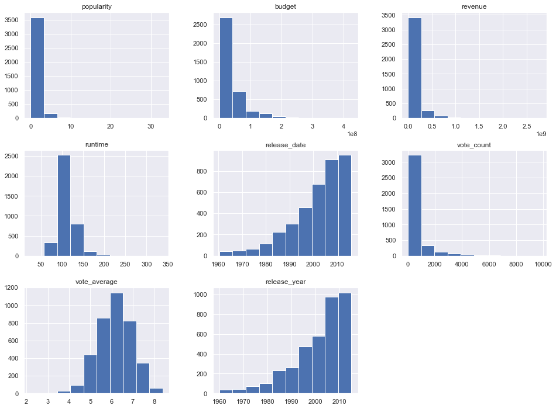

```python
df.hist(figsize=(16,12));
```

To get an overview of these histograms, it is shown that the popularity and vote count of the majority of movies has lower values, while a small number of movies have higher popularity and vote count. For the budget and revenue, it is shown that the majority of film has lower budget and revenue, while small number of films has high budget and high revenue. It is also remarked that for the release date and release year, the number of movies significantly increase after year 2000. Considering the runtime it is shown that the majority of movies has a duration from 90 to 130 minitues. for the vote average, it is shown that it has a normal distribution where a small number of movies has lower and higher vote average.

It is also important to show the correlation between the variables especially with the target variable, the revenue

```python
df.corr()[['revenue']]
```

|  | revenue |
| --- | --- |
| popularity | 0.614035 |
| budget | 0.687636 |
| revenue | 1.000000 |
| runtime | 0.248936 |
| vote_count | 0.753684 |
| vote_average | 0.226112 |
| release_year | 0.141990 |

It is remarked that the popularity, the budget, and vote count have higher correlation with the revnue, where the runtime, vote average and release year have lower correlation.

Note that these statistical observations are described for the numerical variables, while in the following we will also investigate some numerical and categorical variables.

Now we start to answer some questions to get more clarification about the data set.

### Question 1 (Which genres are most frequently seen from year to year?)

```python
df.groupby(['release_year'])[['genres']].max()
```

| release_year | genres |
| --- | --- |
| 1960 | Drama\|Horror\|Thriller |
| 1961 | Western\|Action |
| 1962 | Western\|Action\|Adventure\|Drama |
| 1963 | Horror |
| 1964 | Drama\|Romance |
| 1965 | Drama\|Romance\|War |
| 1966 | Mystery\|Thriller |
| 1967 | Music\|Drama\|Romance |
| 1968 | Western |
| 1969 | History\|Drama\|Western\|Crime |
| 1970 | History\|Action\|Drama\|Adventure\|War |
| 1971 | Science Fiction\|Drama |
| 1972 | Drama\|Crime |
| 1973 | Science Fiction\|Comedy\|Romance |
| 1974 | Horror\|Thriller |
| 1975 | Horror\|Thriller\|Adventure |
| 1976 | Thriller |
| 1977 | Science Fiction\|Fantasy\|Horror\|Drama |
| 1978 | Mystery |
| 1979 | Science Fiction\|Adventure\|Mystery |
| 1980 | Western\|History |
| 1981 | Thriller\|Horror\|Mystery |
| 1982 | War\|Drama\|Romance |
| 1983 | Thriller\|Science Fiction |
| 1984 | War\|Drama\|History |
| 1985 | Science Fiction\|Comedy\|Horror |
| 1986 | Thriller\|Horror |
| 1987 | Science Fiction\|Action\|Adventure\|Thriller |
| 1988 | Thriller\|Drama\|Horror\|Science Fiction |
| 1989 | War |
| 1990 | Thriller\|Crime |
| 1991 | Thriller\|Crime\|Drama |
| 1992 | Western |
| 1993 | Thriller\|Crime |
| 1994 | Thriller\|Science Fiction\|Action\|Crime |
| 1995 | War\|Adventure\|Drama\|Romance |
| 1996 | TV Movie\|Adventure\|Drama\|Science Fiction |
| 1997 | Thriller\|Science Fiction\|Mystery\|Romance |
| 1998 | Thriller\|Crime\|Action |
| 1999 | Thriller\|Science Fiction\|Mystery |
| 2000 | Thriller\|Science Fiction\|Action |
| 2001 | War |
| 2002 | Western\|Animation\|Adventure\|Comedy\|Family |
| 2003 | Western |
| 2004 | Western\|History\|War |
| 2005 | Thriller\|Science Fiction\|Adventure\|Action |
| 2006 | Western\|Drama |
| 2007 | Western |
| 2008 | War\|Drama |
| 2009 | Thriller\|Science Fiction |
| 2010 | Thriller\|Mystery |
| 2011 | War\|Drama |
| 2012 | War\|Action\|Thriller\|Science Fiction |
| 2013 | War\|Action |
| 2014 | Western\|Drama |
| 2015 | Western\|Drama\|Adventure\|Thriller |

```python
df.groupby('release_year').agg(
    popular_genre=pd.NamedAgg(column='genres',aggfunc=pd.Series.max),
    count_genre_per_year=pd.NamedAgg(column='genres',aggfunc=pd.Series.count)
    )
```

| release_year | popular_genre | count_genre_per_year |
| --- | --- | --- |
| 1960 | Drama\|Horror\|Thriller | 5 |
| 1961 | Western\|Action | 10 |
| 1962 | Western\|Action\|Adventure\|Drama | 7 |
| 1963 | Horror | 6 |
| 1964 | Drama\|Romance | 7 |
| 1965 | Drama\|Romance\|War | 5 |
| 1966 | Mystery\|Thriller | 5 |
| 1967 | Music\|Drama\|Romance | 13 |
| 1968 | Western | 9 |
| 1969 | History\|Drama\|Western\|Crime | 4 |
| 1970 | History\|Action\|Drama\|Adventure\|War | 11 |
| 1971 | Science Fiction\|Drama | 13 |
| 1972 | Drama\|Crime | 8 |
| 1973 | Science Fiction\|Comedy\|Romance | 12 |
| 1974 | Horror\|Thriller | 13 |
| 1975 | Horror\|Thriller\|Adventure | 9 |
| 1976 | Thriller | 15 |
| 1977 | Science Fiction\|Fantasy\|Horror\|Drama | 19 |
| 1978 | Mystery | 16 |
| 1979 | Science Fiction\|Adventure\|Mystery | 16 |
| 1980 | Western\|History | 23 |
| 1981 | Thriller\|Horror\|Mystery | 30 |
| 1982 | War\|Drama\|Romance | 25 |
| 1983 | Thriller\|Science Fiction | 31 |
| 1984 | War\|Drama\|History | 42 |
| 1985 | Science Fiction\|Comedy\|Horror | 40 |
| 1986 | Thriller\|Horror | 47 |
| 1987 | Science Fiction\|Action\|Adventure\|Thriller | 46 |
| 1988 | Thriller\|Drama\|Horror\|Science Fiction | 56 |
| 1989 | War | 51 |
| 1990 | Thriller\|Crime | 51 |
| 1991 | Thriller\|Crime\|Drama | 49 |
| 1992 | Western | 53 |
| 1993 | Thriller\|Crime | 68 |
| 1994 | Thriller\|Science Fiction\|Action\|Crime | 62 |
| 1995 | War\|Adventure\|Drama\|Romance | 77 |
| 1996 | TV Movie\|Adventure\|Drama\|Science Fiction | 85 |
| 1997 | Thriller\|Science Fiction\|Mystery\|Romance | 90 |
| 1998 | Thriller\|Crime\|Action | 92 |
| 1999 | Thriller\|Science Fiction\|Mystery | 114 |
| 2000 | Thriller\|Science Fiction\|Action | 106 |
| 2001 | War | 121 |
| 2002 | Western\|Animation\|Adventure\|Comedy\|Family | 125 |
| 2003 | Western | 117 |
| 2004 | Western\|History\|War | 145 |
| 2005 | Thriller\|Science Fiction\|Adventure\|Action | 163 |
| 2006 | Western\|Drama | 167 |
| 2007 | Western | 162 |
| 2008 | War\|Drama | 165 |
| 2009 | Thriller\|Science Fiction | 172 |
| 2010 | Thriller\|Mystery | 177 |
| 2011 | War\|Drama | 193 |
| 2012 | War\|Action\|Thriller\|Science Fiction | 151 |
| 2013 | War\|Action | 174 |
| 2014 | Western\|Drama | 164 |
| 2015 | Western\|Drama\|Adventure\|Thriller | 160 |

If we need to arrange the genre according to its count over all the years, it is given as:

```python
df.value_counts(['release_year','genres'])
```

```
release_year  genres
2014          Drama                               23
2006          Drama                               19
2013          Comedy                              17
2004          Comedy                              16
2011          Comedy                              15
                                                  ..
1997          Drama|Horror|Mystery|Thriller        1
              Drama|Mystery|Thriller|Crime         1
              Drama|Romance|Thriller               1
              Drama|Science Fiction|Mystery        1
2015          Western|Drama|Adventure|Thriller     1
Length: 2692, dtype: int64
```

### Question 2 (What kinds of properties are associated with movies that have high revenues?)

Here are the top ten rows shown the higest revenue and the other variable associated with this high revenue

```python
df.sort_values('revenue', ascending=False).head(10)
```

|  | popularity | budget | revenue | original_title | cast | director | runtime | genres | release_date | vote_count | vote_average | release_year |
| --- | --- | --- | --- | --- | --- | --- | --- | --- | --- | --- | --- | --- |
| 1386 | 9.432768 | 237000000 | 2781505847 | Avatar | Sam Worthington\|Zoe Saldana\|Sigourney Weaver\|S... | James Cameron | 162 | Action\|Adventure\|Fantasy\|Science Fiction | 2009-12-10 | 8458 | 7.1 | 2009 |
| 3 | 11.173104 | 200000000 | 2068178225 | Star Wars: The Force Awakens | Harrison Ford\|Mark Hamill\|Carrie Fisher\|Adam D... | J.J. Abrams | 136 | Action\|Adventure\|Science Fiction\|Fantasy | 2015-12-15 | 5292 | 7.5 | 2015 |
| 5231 | 4.355219 | 200000000 | 1845034188 | Titanic | Kate Winslet\|Leonardo DiCaprio\|Frances Fisher\|... | James Cameron | 194 | Drama\|Romance\|Thriller | 1997-11-18 | 4654 | 7.3 | 1997 |
| 4361 | 7.637767 | 220000000 | 1519557910 | The Avengers | Robert Downey Jr.\|Chris Evans\|Mark Ruffalo\|Chr... | Joss Whedon | 143 | Science Fiction\|Action\|Adventure | 2012-04-25 | 8903 | 7.3 | 2012 |
| 0 | 32.985763 | 150000000 | 1513528810 | Jurassic World | Chris Pratt\|Bryce Dallas Howard\|Irrfan Khan\|Vi... | Colin Trevorrow | 124 | Action\|Adventure\|Science Fiction\|Thriller | 2015-06-09 | 5562 | 6.5 | 2015 |
| 4 | 9.335014 | 190000000 | 1506249360 | Furious 7 | Vin Diesel\|Paul Walker\|Jason Statham\|Michelle ... | James Wan | 137 | Action\|Crime\|Thriller | 2015-04-01 | 2947 | 7.3 | 2015 |
| 14 | 5.944927 | 280000000 | 1405035767 | Avengers: Age of Ultron | Robert Downey Jr.\|Chris Hemsworth\|Mark Ruffalo... | Joss Whedon | 141 | Action\|Adventure\|Science Fiction | 2015-04-22 | 4304 | 7.4 | 2015 |
| 3374 | 5.711315 | 125000000 | 1327817822 | Harry Potter and the Deathly Hallows: Part 2 | Daniel Radcliffe\|Rupert Grint\|Emma Watson\|Alan... | David Yates | 130 | Adventure\|Family\|Fantasy | 2011-07-07 | 3750 | 7.7 | 2011 |
| 5422 | 6.112766 | 150000000 | 1274219009 | Frozen | Kristen Bell\|Idina Menzel\|Jonathan Groff\|Josh ... | Chris Buck\|Jennifer Lee | 102 | Animation\|Adventure\|Family | 2013-11-27 | 3369 | 7.5 | 2013 |
| 5425 | 4.946136 | 200000000 | 1215439994 | Iron Man 3 | Robert Downey Jr.\|Gwyneth Paltrow\|Guy Pearce\|D... | Shane Black | 130 | Action\|Adventure\|Science Fiction | 2013-04-18 | 6882 | 6.9 | 2013 |

It can be shown that the movie with maximum revenue is with title "Avater" whose director is "James Cameron" and the other properties are presented.

To get also the least ten movies based on its revenue are shown as the following:

```python
df.sort_values('revenue', ascending=False).tail(10)
```

|  | popularity | budget | revenue | original_title | cast | director | runtime | genres | release_date | vote_count | vote_average | release_year |
| --- | --- | --- | --- | --- | --- | --- | --- | --- | --- | --- | --- | --- |
| 3788 | 0.189663 | 3000000 | 22000 | The Divide | Lauren German\|Michael Biehn\|Milo Ventimiglia\|C... | Xavier Gens | 112 | Science Fiction | 2011-03-13 | 86 | 5.6 | 2011 |
| 7637 | 0.323370 | 15000000 | 20380 | The Good Night | Penélope Cruz\|Martin Freeman\|Gwyneth Paltrow\|... | Jake Paltrow | 93 | Comedy\|Drama\|Romance\|Fantasy\|Music | 2007-01-25 | 16 | 5.5 | 2007 |
| 4535 | 0.557044 | 13000000 | 18295 | Venuto al mondo | Penélope Cruz\|Emile Hirsch\|Adnan Haskovic\|Pie... | Sergio Castellitto | 127 | Drama\|Romance\|War | 2012-09-13 | 80 | 6.8 | 2012 |
| 1561 | 0.534693 | 3000000 | 18097 | Women in Trouble | Carla Gugino\|Adrianne Palicki\|Connie Britton\|M... | Sebastian Gutierrez | 92 | Comedy\|Drama | 2009-11-13 | 11 | 4.5 | 2009 |
| 3573 | 0.539108 | 20000000 | 17479 | 5 Days of War | Rupert Friend\|Val Kilmer\|Andy García\|Dean Cai... | Renny Harlin | 113 | War\|Drama | 2011-04-14 | 29 | 5.9 | 2011 |
| 331 | 0.365901 | 10000000 | 17472 | Strangerland | Nicole Kidman\|Joseph Fiennes\|Hugo Weaving\|Lisa... | Kim Farrant | 111 | Drama\|Thriller | 2015-07-01 | 48 | 5.0 | 2015 |
| 818 | 0.728025 | 6000000 | 15071 | Barefoot | Evan Rachel Wood\|Scott Speedman\|J.K. Simmons\|T... | Andrew Fleming | 90 | Comedy\|Drama\|Romance | 2014-02-02 | 129 | 6.5 | 2014 |
| 9638 | 0.447184 | 10000000 | 14000 | Cherry 2000 | Melanie Griffith\|David Andrews\|Pamela Gidley\|B... | Steve De Jarnatt | 99 | Science Fiction | 1987-11-12 | 35 | 6.0 | 1987 |
| 6274 | 0.792950 | 12000000 | 10289 | Chaos | Jason Statham\|Ryan Phillippe\|Wesley Snipes\|Hen... | Tony Giglio | 106 | Drama\|Action\|Crime | 2005-01-17 | 162 | 6.3 | 2005 |
| 1871 | 0.092519 | 31192 | 10000 | Down Terrace | Robert Hill\|Robin Hill\|Julia Deakin\|David Scha... | Ben Wheatley | 89 | Drama\|Action\|Comedy | 2009-09-01 | 15 | 6.5 | 2009 |

It can be remarked that the least movies has revenues which are less that the budget used for its production.

Especially, To show the movie genre which have the maximum revenue

```python
df.groupby('genres')[['revenue']].max().sort_values('revenue', ascending=False)
```

| genres | revenue |
| --- | --- |
| Action\|Adventure\|Fantasy\|Science Fiction | 2781505847 |
| Action\|Adventure\|Science Fiction\|Fantasy | 2068178225 |
| Drama\|Romance\|Thriller | 1845034188 |
| Science Fiction\|Action\|Adventure | 1519557910 |
| Action\|Adventure\|Science Fiction\|Thriller | 1513528810 |
| ... | ... |
| Fantasy\|Thriller | 45431 |
| Drama\|Action\|Comedy\|Crime | 44462 |
| Horror\|Crime\|Mystery\|Thriller | 31081 |
| Comedy\|Drama\|Romance\|Fantasy\|Music | 20380 |
| Drama\|Action\|Comedy | 10000 |

1043 rows × 1 columns

### Question 3 (What is the total revenue in each year ?)

To show the total revenue according to the releasr year:

```python
df.groupby('release_year')[['revenue']].sum()
```

| release_year | revenue |
| --- | --- |
| 1960 | 129005000 |
| 1961 | 337720188 |
| 1962 | 206329846 |
| 1963 | 176526882 |
| 1964 | 328613548 |
| 1965 | 458081854 |
| 1966 | 84736689 |
| 1967 | 731834637 |
| 1968 | 222221762 |
| 1969 | 229707076 |
| 1970 | 549971969 |
| 1971 | 376286710 |
| 1972 | 480900171 |
| 1973 | 1115013099 |
| 1974 | 720167027 |
| 1975 | 845307270 |
| 1976 | 749926536 |
| 1977 | 1882158485 |
| 1978 | 1171270089 |
| 1979 | 1181030150 |
| 1980 | 1322115664 |
| 1981 | 1612001458 |
| 1982 | 2155656345 |
| 1983 | 1990300842 |
| 1984 | 2406485095 |
| 1985 | 2256474683 |
| 1986 | 2179351003 |
| 1987 | 2757476732 |
| 1988 | 3126287459 |
| 1989 | 4571930268 |
| 1990 | 4651535788 |
| 1991 | 4363121407 |
| 1992 | 5086371608 |
| 1993 | 6176513816 |
| 1994 | 6523191415 |
| 1995 | 8228517662 |
| 1996 | 7719318773 |
| 1997 | 10408527923 |
| 1998 | 9226155395 |
| 1999 | 11350984043 |
| 2000 | 10949974823 |
| 2001 | 13248323875 |
| 2002 | 14410416070 |
| 2003 | 14757992327 |
| 2004 | 16485281178 |
| 2005 | 16090398939 |
| 2006 | 15640510653 |
| 2007 | 18640661952 |
| 2008 | 18949929956 |
| 2009 | 21607125550 |
| 2010 | 21804360433 |
| 2011 | 23405265343 |
| 2012 | 24151037391 |
| 2013 | 24350634456 |
| 2014 | 24069960039 |
| 2015 | 26202922801 |

### To show the capability of python function to simplify the analysis, a line_plot function is created to be used for line plot

```python
def line_plot(dataF,fig_title,x_label,y_label,fs):
    dataF.plot(figsize=(9,7))
    plt.title(fig_title, fontsize=fs)
    plt.xlabel(x_label, fontsize=fs)
    plt.ylabel(y_label, fontsize=fs)
    plt.show()
```

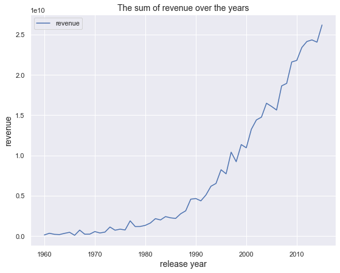

```python
df_rev_year = df.groupby('release_year')[['revenue']].sum()
line_plot(df_rev_year,'The sum of revenue over the years', 'release year', 'revenue',14)
```

### Question 4 (Explain the relation between the total budget and the total revenue in each year ?)

To show the total budget and the total revenue according to the releasr year:

```python
df.groupby('release_year')[['budget','revenue']].sum()
```

| release_year | budget | revenue |
| --- | --- | --- |
| 1960 | 20806948 | 129005000 |
| 1961 | 38637000 | 337720188 |
| 1962 | 39450000 | 206329846 |
| 1963 | 61115000 | 176526882 |
| 1964 | 33935161 | 328613548 |
| 1965 | 58800000 | 458081854 |
| 1966 | 32268000 | 84736689 |
| 1967 | 95500000 | 731834637 |
| 1968 | 53950000 | 222221762 |
| 1969 | 22844087 | 229707076 |
| 1970 | 95901946 | 549971969 |
| 1971 | 40002000 | 376286710 |
| 1972 | 23664254 | 480900171 |
| 1973 | 57327000 | 1115013099 |
| 1974 | 69585000 | 720167027 |
| 1975 | 37100000 | 845307270 |
| 1976 | 120500000 | 749926536 |
| 1977 | 138850000 | 1882158485 |
| 1978 | 166170000 | 1171270089 |
| 1979 | 230700000 | 1181030150 |
| 1980 | 320050000 | 1322115664 |
| 1981 | 291750000 | 1612001458 |
| 1982 | 343900000 | 2155656345 |
| 1983 | 485227000 | 1990300842 |
| 1984 | 573046964 | 2406485095 |
| 1985 | 596275523 | 2256474683 |
| 1986 | 629100000 | 2179351003 |
| 1987 | 608930006 | 2757476732 |
| 1988 | 811300000 | 3126287459 |
| 1989 | 967989360 | 4571930268 |
| 1990 | 1196631000 | 4651535788 |
| 1991 | 1290000000 | 4363121407 |
| 1992 | 1213325538 | 5086371608 |
| 1993 | 1572685552 | 6176513816 |
| 1994 | 1818807000 | 6523191415 |
| 1995 | 2608019363 | 8228517662 |
| 1996 | 2967692051 | 7719318773 |
| 1997 | 4028286675 | 10408527923 |
| 1998 | 3952010000 | 9226155395 |
| 1999 | 4917775000 | 11350984043 |
| 2000 | 4839200000 | 10949974823 |
| 2001 | 5226279000 | 13248323875 |
| 2002 | 5402840159 | 14410416070 |
| 2003 | 5437837384 | 14757992327 |
| 2004 | 6640192308 | 16485281178 |
| 2005 | 6830945941 | 16090398939 |
| 2006 | 6828218000 | 15640510653 |
| 2007 | 6925561892 | 18640661952 |
| 2008 | 7113176800 | 18949929956 |
| 2009 | 7535827844 | 21607125550 |
| 2010 | 8463138436 | 21804360433 |
| 2011 | 8433042429 | 23405265343 |
| 2012 | 7560510500 | 24151037391 |
| 2013 | 8523422753 | 24350634456 |
| 2014 | 7392768000 | 24069960039 |
| 2015 | 7170777528 | 26202922801 |

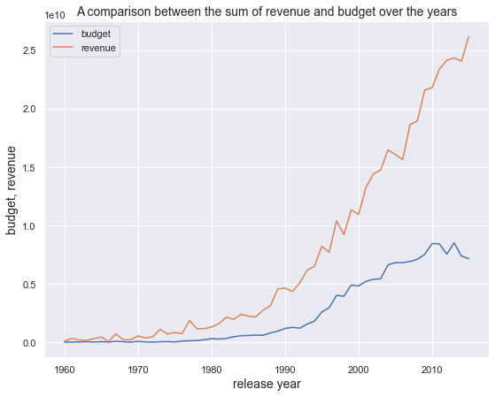

```python
df_rev_bud_year=df.groupby('release_year')[['budget','revenue']].sum()
line_plot(df_rev_bud_year,'A comparison between the sum of revenue and budget over the years', 'release year', 'budget, revenue',14)
```

It can be shown that as the budget increases, the revenue also more increases.

### Question 5 (Explain the relation between the total budget and the total revenue according to movie title ?)

To show the total budget and the total revenue according to the movie title, some of these movies are presented as follows:

```python
df.groupby('original_title')[['budget','revenue']].sum().head(10)
```

| original_title | budget | revenue |
| --- | --- | --- |
| (500) Days of Summer | 7500000 | 60722734 |
| 10 Things I Hate About You | 16000000 | 53478166 |
| 10,000 BC | 105000000 | 266000000 |
| 101 Dalmatians | 54000000 | 320689294 |
| 102 Dalmatians | 85000000 | 183611771 |
| 10th & Wolf | 8000000 | 143451 |
| 12 Rounds | 20000000 | 17280326 |
| 12 Years a Slave | 20000000 | 187000000 |
| 127 Hours | 18000000 | 35692920 |
| 13 Going On 30 | 37000000 | 96455697 |

The following figure shows a bar chart of some of these movies.

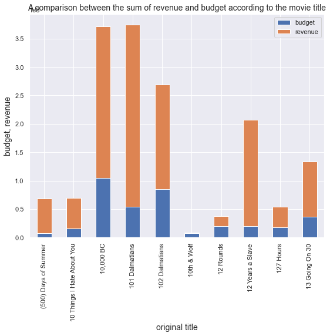

```python
df.groupby('original_title')[['budget','revenue']].sum().head(10).plot(kind='bar',  figsize = (9,7), grid = True, stacked=True)
plt.xlabel('original title', fontsize=14);
plt.ylabel('budget, revenue', fontsize=14);
plt.title('A comparison between the sum of revenue and budget according to the movie title', fontsize=14);
```

### Question 6 (Is there a relation between the director name and the total revenue? Explain?)

The top ten directors, which provides movies with **total** revenue is presented

```python
df.groupby('director')[['revenue']].sum().sort_values('revenue', ascending=False).head(10)
```

| director | revenue |
| --- | --- |
| Steven Spielberg | 9018563772 |
| Peter Jackson | 6523244659 |
| James Cameron | 5841894863 |
| Michael Bay | 4917208171 |
| Christopher Nolan | 4167548502 |
| David Yates | 4154295625 |
| Robert Zemeckis | 3869690869 |
| Chris Columbus | 3725631503 |
| Tim Burton | 3665414624 |
| Ridley Scott | 3584430808 |

It is shown that the movies of the director Steven Spielberg have the total revenue.

The top ten directors, which provides movies with **maximum** revenue is presented

```python
df.groupby('director')[['revenue']].max().sort_values('revenue', ascending=False).head(10)
```

| director | revenue |
| --- | --- |
| James Cameron | 2781505847 |
| J.J. Abrams | 2068178225 |
| Joss Whedon | 1519557910 |
| Colin Trevorrow | 1513528810 |
| James Wan | 1506249360 |
| David Yates | 1327817822 |
| Chris Buck\|Jennifer Lee | 1274219009 |
| Shane Black | 1215439994 |
| Kyle Balda\|Pierre Coffin | 1156730962 |
| Michael Bay | 1123746996 |

To show the top ten directors, which provides movies with **maximum** revenue according to the release year is presented

```python
df.groupby(['release_year', 'director'])[['revenue']].max().sort_values('revenue', ascending=False).head(10)
```

| release_year | director | revenue |
| --- | --- | --- |
| 2009 | James Cameron | 2781505847 |
| 2015 | J.J. Abrams | 2068178225 |
| 1997 | James Cameron | 1845034188 |
| 2012 | Joss Whedon | 1519557910 |
| 2015 | Colin Trevorrow | 1513528810 |
|  | James Wan | 1506249360 |
|  | Joss Whedon | 1405035767 |
| 2011 | David Yates | 1327817822 |
| 2013 | Chris Buck\|Jennifer Lee | 1274219009 |
|  | Shane Black | 1215439994 |

It is shown that the movies of the director James Cameron have the **maximum** revenue in 2009.

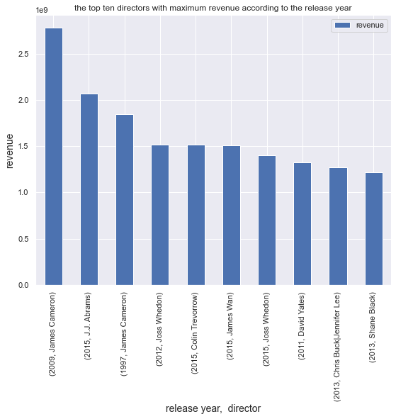

```python
df.groupby(['release_year', 'director'])[['revenue']].max().sort_values('revenue', ascending=False).head(10).plot(kind='bar', figsize = (9,7));
plt.xlabel('release year,  director', fontsize=14);
plt.ylabel('revenue', fontsize=14);
plt.title('the top ten directors with maximum revenue according to the release year');
```

```python
df.groupby('cast')[['revenue']].max()
```

| cast | revenue |
| --- | --- |
| 50 Cent\|Joy Bryant\|Adewale Akinnuoye-Agbaje\|Omar Benson Miller\|Terrence Howard | 46442528 |
| Aamir Khan\|Asin Thottumkal\|Jiah Khan\|Pradeep Ram Singh Rawat | 76000000 |
| Aamir Khan\|Kareena Kapoor\|Madhavan\|Sharman Joshi\|Boman Irani | 70000000 |
| Aamir Khan\|Saif Ali Khan\|Akshaye Khanna\|Preity Zinta\|Sonali Kulkarni | 4099000 |
| Aaron Eckhart\|Hilary Swank\|Delroy Lindo\|Stanley Tucci\|TchÃ©ky Karyo | 74208267 |
| ... | ... |
| Zana MarjanoviÄ‡\|Goran KostiÄ‡\|Branko ÄuriÄ‡\|Dzana Pinjo\|MiloÅ¡ TimotijeviÄ‡ | 303877 |
| Zhang Ziyi\|Gong Li\|Youki Kudoh\|Tsai Chin\|Suzuka Ohgo | 162242962 |
| Zoe Saldana\|Cliff Curtis\|Callum Blue\|Michael Vartan\|Lennie James | 60965854 |
| Zoe Saldana\|James Marsden\|Martin Lawrence\|Peter Dinklage\|Danny Glover | 49050886 |
| Zoe Sloane\|Jade Viggiano\|Amancaya Aguilar\|Kahiry Bess\|Alisha Naragsheth | 103735 |

3776 rows × 1 columns

### Question 7 (Explain the relation between the total budget and the total revenue according to vote count and vote average?)

To show the total budget and the total revenue according to the vote count and vote average:

```python
df.groupby('vote_count').max().sort_values('vote_count', ascending=False)[['revenue', 'budget']]
```

| vote_count | revenue | budget |
| --- | --- | --- |
| 9767 | 825500000 | 160000000 |
| 8903 | 1519557910 | 220000000 |
| 8458 | 2781505847 | 237000000 |
| 8432 | 1001921825 | 185000000 |
| 7375 | 425368238 | 100000000 |
| ... | ... | ... |
| 14 | 161000000 | 30000000 |
| 13 | 50000000 | 20000000 |
| 12 | 11838218 | 65000000 |
| 11 | 15500000 | 35000000 |
| 10 | 37672350 | 32000000 |

1274 rows × 2 columns

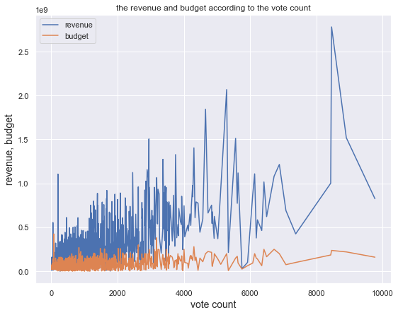

```python
df.groupby('vote_count').max().sort_values('vote_count', ascending=False)[['revenue', 'budget']].plot(figsize=(9,7))
plt.xlabel('vote count', fontsize=14);
plt.ylabel('revenue, budget', fontsize=14);
plt.title('the revenue and budget according to the vote count');
```

```python
df.groupby('vote_average').max().sort_values('vote_average', ascending=False)[['revenue', 'budget']]
```

| vote_average | revenue | budget |
| --- | --- | --- |
| 8.4 | 28341469 | 25000000 |
| 8.3 | 245066411 | 6000000 |
| 8.2 | 13993093 | 3300000 |
| 8.1 | 1001921825 | 185000000 |
| 8.0 | 853708609 | 175000000 |
| 7.9 | 1118888979 | 170000000 |
| 7.8 | 926287400 | 165000000 |
| 7.7 | 1327817822 | 178000000 |
| 7.6 | 958400000 | 250000000 |
| 7.5 | 2068178225 | 250000000 |
| 7.4 | 1405035767 | 280000000 |
| 7.3 | 1845034188 | 260000000 |
| 7.2 | 976475550 | 150000000 |
| 7.1 | 2781505847 | 250000000 |
| 7.0 | 970761885 | 200000000 |
| 6.9 | 1215439994 | 250000000 |
| 6.8 | 1108561013 | 300000000 |
| 6.7 | 694713380 | 200000000 |
| 6.6 | 821708551 | 200000000 |
| 6.5 | 1513528810 | 225000000 |
| 6.4 | 886686817 | 425000000 |
| 6.3 | 1025467110 | 380000000 |
| 6.2 | 880674609 | 245000000 |
| 6.1 | 1123746996 | 225000000 |
| 6.0 | 836297228 | 260000000 |
| 5.9 | 698491347 | 210000000 |
| 5.8 | 890871626 | 258000000 |
| 5.7 | 396600000 | 180000000 |
| 5.6 | 1106279658 | 200000000 |
| 5.5 | 563749323 | 209000000 |
| 5.4 | 371876278 | 163000000 |
| 5.3 | 569651467 | 270000000 |
| 5.2 | 336529144 | 176000003 |
| 5.1 | 401128639 | 200000000 |
| 5.0 | 341631208 | 135000000 |
| 4.9 | 179179718 | 120000000 |
| 4.8 | 249288105 | 100000000 |
| 4.7 | 318502923 | 150000000 |
| 4.6 | 266586800 | 100000000 |
| 4.5 | 101758490 | 70000000 |
| 4.4 | 238207122 | 160000000 |
| 4.3 | 82102379 | 100000000 |
| 4.2 | 149673788 | 79000000 |
| 4.1 | 99423521 | 50000000 |
| 4.0 | 84646831 | 76000000 |
| 3.9 | 51376861 | 35000000 |
| 3.8 | 36450736 | 54000000 |
| 3.7 | 51881013 | 23000000 |
| 3.6 | 35000000 | 25000000 |
| 3.5 | 10442808 | 20000000 |
| 3.4 | 86865564 | 20000000 |
| 3.3 | 18902015 | 40000000 |
| 2.2 | 73706 | 65000000 |

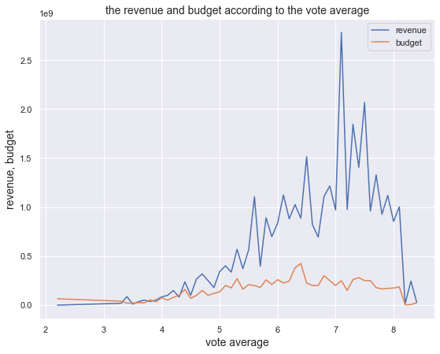

```python
df.groupby('vote_average').max().sort_values('vote_average', ascending=False)[['revenue', 'budget']].plot(figsize=(9,7))
plt.xlabel('vote average', fontsize=14);
plt.ylabel('revenue, budget', fontsize=14);
plt.title('the revenue and budget according to the vote average', fontsize=14);
plt.show()
```

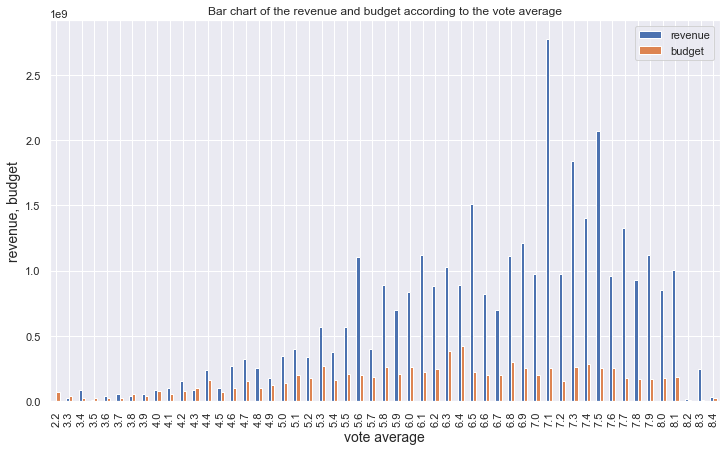

```python
df.groupby('vote_average').max().sort_values('vote_average', ascending=True)[['revenue', 'budget']].plot(kind='bar',figsize=(12,7))
plt.xlabel('vote average', fontsize=14);
plt.ylabel('revenue, budget', fontsize=14);
plt.title('Bar chart of the revenue and budget according to the vote average');
plt.show()
```

It is remarked that for the minimum vote average, the budget is greater than the revenue. Also its remarked that the high vote average was given for low revenue and budget.

A boxplot is drawn for the vote average as shown to discover if there are outliers and discover its statitical properties

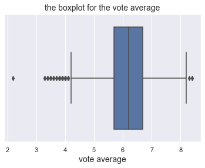

```python
sns.boxplot(x=df['vote_average'], data=df)
sns.set(rc={'figure.figsize':(8,6)})
plt.xlabel('vote average', fontsize=14);
plt.title('the boxplot for the vote average', fontsize=14);
```

## Conclusions

This project introduced an analysis of the dataset associated with The Movie Database (TMDB). The project starts by cleaning the data to put it in the most clean form to get a good exploratory analysis. Some questions are answered to get more insight into the dataset analysis. Some visualization plots are also presented to get more clarifications about the proposed analysis. Although, there are many questions can be proposed and answered, these proposed questions are presented as a sample of questions that add value for the analysis of the dataset. It is found that the effect of budget is very important to gain high revenue. it is remarked also the number of movies has highly increases after the year 2000. It is also remarked that the vote count realy refer to films with high revenue. Although, the data is cleaned to a good extent, the dataset need to be updated and more correct data need to be added. For completing this project, alot of search on the internet are made and a lot of sites are visited. Sample of the visited sites and reference books are presented in Reference section.

# References

- [Kaggle](https://www.kaggle.com/tmdb/tmdb-movie-metadata)
- [Stack Overflow](https://stackoverflow.com/)
- [Pandas documentation site](https://pandas.pydata.org/pandas-docs/stable/index.html)
- [dataindependent](https://dataindependent.com/pandas/)
- [datascientyst site](https://datascientyst.com/pandas-groupby-count/)
- McKinney, W. (2012). Python for data analysis: Data wrangling with Pandas, NumPy, and IPython. " O'Reilly Media, Inc.".